# Data Wrangling and Analysis

## Import Library dan Deklarasi Function

```r
library(dplyr)
library(ggplot2)
library(nycflights13)
library(lubridate)
library(corrplot)
library(reshape2)
```

### Fungsi `cekNa`

Fungsi ini berguna untuk menghitung jumlah NA pada setiap kolom

```r
cekNa <- function (data){
      sapply(data, function(x) sum(is.na(x)))
}
```

### Fungsi `convertToDate`

Fungsi ini berguna untuk menggabungkan tanggal yang terpisah

```r
convertToDate <- function(year, month, day, hour_minute){
      ymd_hm(paste(paste(year, month, day, sep = "-"),
                   paste(floor(hour_minute / 100), hour_minute %% 100, sep = ":")))
}
```

## Data Cleaning dan Integration

Flight data merupakan data penerbangan dari tanggal 1 Januari 2013 sampai 31 Desember 2013 di 3 bandara yang ada di New York City, yaitu Bandara International John F Kennedy (JFK), Bandara La Guardia (LGA) dan Bandara International Newark Liberty (EWR). Data ini berasal dari library [`nycflights13`](https://cran.r-project.org/web/packages/nycflights13/nycflights13.pdf).

```r
data("flights")
sample_n(flights, 7)
```

```
## # A tibble: 7 x 19
##    year month   day dep_time sched_dep_time dep_delay arr_time sched_arr_time
##   <int> <int> <int>    <int>          <int>     <dbl>    <int>          <int>
## 1  2013    12    15     1249           1205        44     1420           1350
## 2  2013     8    11     1225           1230        -5     1346           1352
## 3  2013     1    29      858            905        -7     1011           1029
## 4  2013     4     3      604            610        -6      720            745
## 5  2013     9    12     1001           1005        -4     1221           1214
## 6  2013     6    25     1722           1700        22     2034           2000
## 7  2013    10     8     1858           1900        -2     2151           2235
## # ... with 11 more variables: arr_delay <dbl>, carrier <chr>, flight <int>,
## #   tailnum <chr>, origin <chr>, dest <chr>, air_time <dbl>, distance <dbl>,
## #   hour <dbl>, minute <dbl>, time_hour <dttm>
```

Pada library `nycflights13` tersedia juga data lainnya yang mendukung data flight tersebut. 1. Data weather, yaitu data yang berisi tentang cuaca pada tiga bandara tersebut selama tahun 2013

```r
data("weather")
sample_n(weather, 7)
```

```
## # A tibble: 7 x 15
##   origin  year month   day  hour  temp  dewp humid wind_dir wind_speed wind_gust
##   <chr>  <int> <int> <int> <int> <dbl> <dbl> <dbl>    <dbl>      <dbl>     <dbl>
## 1 JFK     2013    11    16    14  54.0 46.0   74.5      190      10.4       NA
## 2 LGA     2013     2     4    21  30.0  8.96  40.6      270       8.06      NA
## 3 LGA     2013     5    21    11  82.0 64.9   56.2      210      10.4       NA
## 4 LGA     2013    12    30     9  44.1 33.1   65.1      260      13.8       NA
## 5 LGA     2013    11    19    13  46.9 27.0   45.5      330      19.6       34.5
## 6 LGA     2013     4    13    23  48.9 41     74.0      180       5.75      NA
## 7 JFK     2013    11    10     0  48.0 36.0   62.8      220      13.8       NA
## # ... with 4 more variables: precip <dbl>, pressure <dbl>, visib <dbl>,
## #   time_hour <dttm>
```

2. Data airlines, yaitu data nama maskapai yang melakukan penerbangan ditiga bandara tersebut

```r
data("airlines")
sample_n(airlines, 7)
```

```
## # A tibble: 7 x 2
##   carrier name
##   <chr>   <chr>
## 1 MQ      Envoy Air
## 2 F9      Frontier Airlines Inc.
## 3 YV      Mesa Airlines Inc.
## 4 DL      Delta Air Lines Inc.
## 5 US      US Airways Inc.
## 6 OO      SkyWest Airlines Inc.
## 7 AA      American Airlines Inc.
```

3. Data airports, yaitu data mengenai bandara yang ada di America

```r
data("airports")
sample_n(airports, 7)
```

```
## # A tibble: 7 x 8
##   faa   name                        lat    lon   alt    tz dst   tzone
##   <chr> <chr>                     <dbl>  <dbl> <dbl> <dbl> <chr> <chr>
## 1 ONT   Ontario Intl               34.1 -118.    944    -8 A     America/Los_An~
## 2 6A2   Griffin-Spalding County ~  33.2  -84.3   958    -5 A     America/New_Yo~
## 3 KGX   Grayling Airport           62.9 -160.     99    -9 A     America/Anchor~
## 4 SXP   Sheldon Point Airport      62.5 -165.     12    -9 A     America/Anchor~
## 5 CDK   CedarKey                   29.1  -83.1    11    -5 A     America/New_Yo~
## 6 FIT   Fitchburg Municipal Airp~  42.6  -71.8   348    -5 A     America/New_Yo~
## 7 PYM   Plymouth Municipal Airpo~  41.9  -70.7   148    -5 A     America/New_Yo~
```

```r
data("airports")
sample_n(airports, 7)
```

```
## # A tibble: 7 x 8
##   faa   name                           lat    lon   alt    tz dst   tzone
##   <chr> <chr>                        <dbl>  <dbl> <dbl> <dbl> <chr> <chr>
## 1 BOI   Boise Air Terminal            43.6 -116.   2871    -7 A     America/Den~
## 2 GGW   Wokal Field Glasgow Interna~  48.2 -107.   2296    -7 A     America/Den~
## 3 Y72   Bloyer Field                  44.0  -90.5   966    -6 A     America/Chi~
## 4 UDG   Darlington County Jetport     34.4  -79.9   192    -5 A     America/New~
## 5 AAP   Andrau Airport                29.4  -95.4    80    -6 A     America/Chi~
## 6 WTL   Tuntutuliak Airport           60.3 -163.     16    -9 A     America/Anc~
## 7 FRN   Bryant Ahp                    61.3 -150.    378    -9 A     America/Anc~
```

### Menghapus data yang tidak legkap

```r
cekNa(flights)
```

```
##           year          month            day       dep_time sched_dep_time
##              0              0              0           8255              0
##      dep_delay       arr_time sched_arr_time      arr_delay        carrier
##           8255           8713              0           9430              0
##         flight        tailnum         origin           dest       air_time
##              0           2512              0              0           9430
##       distance           hour         minute      time_hour
##              0              0              0              0
```

Terlihat bahwa 6 kolom yang masih mengandung NA. Agar memudahkan analisis maka data tersebut akan dihilangkan

```r
data <- na.omit(flights)
cekNa(data)
```

```
##           year          month            day       dep_time sched_dep_time
##              0              0              0              0              0
##      dep_delay       arr_time sched_arr_time      arr_delay        carrier
##              0              0              0              0              0
##         flight        tailnum         origin           dest       air_time
##              0              0              0              0              0
##       distance           hour         minute      time_hour
##              0              0              0              0
```

### Menghapus kolom yang tidak diperlukan

```r
data <- data %>%
      select(-c(arr_time, sched_arr_time, flight, air_time, minute)) %>%
      mutate(sched_dep_time = convertToDate(2013, month, day, sched_dep_time),
             dep_time = sched_dep_time + dep_delay * 60)
sample_n(data, 7)
```

```
## # A tibble: 7 x 14
##    year month   day dep_time            sched_dep_time      dep_delay arr_delay
##   <int> <int> <int> <dttm>              <dttm>                  <dbl>     <dbl>
## 1  2013     4    11 2013-04-11 22:38:00 2013-04-11 19:40:00       178       140
## 2  2013     3    23 2013-03-23 11:11:00 2013-03-23 11:15:00        -4         9
## 3  2013     3    29 2013-03-29 09:47:00 2013-03-29 09:50:00        -3       -24
## 4  2013    10    10 2013-10-10 15:16:00 2013-10-10 15:05:00        11         7
## 5  2013     9     4 2013-09-04 08:11:00 2013-09-04 08:10:00         1       -14
## 6  2013     5    26 2013-05-26 09:07:00 2013-05-26 08:19:00        48        30
## 7  2013     2     4 2013-02-04 13:26:00 2013-02-04 13:20:00         6        -6
## # ... with 7 more variables: carrier <chr>, tailnum <chr>, origin <chr>,
## #   dest <chr>, distance <dbl>, hour <dbl>, time_hour <dttm>
```

### Integrasi dengan dataset lainnya

Saya menggabungkan 4 dataset dengan data flights ini, data yang digabungkan adalah kolom yang akan digunakan untuk melakukan analisis kedepannya.

```r
data <- data %>%
            left_join(select(weather, -c(dewp, wind_dir, wind_gust, precip)),
                      by = c("origin", "time_hour", "month", "day", "year", "hour")) %>%
            left_join(select(airports, faa, name),
                      by = c("origin" = "faa")) %>%
            select(-year) %>%
            rename(dep_airport = name) %>%
            left_join(select(airports, faa, name),
                      by = c("dest" = "faa")) %>%
            rename(dest_airport = name) %>%
            left_join(select(planes, tailnum, year, engine),
                      by = "tailnum") %>%
            rename(year_aiplane = year) %>%
            left_join(airlines, by = "carrier")
sample_n(data, 7)
```

```
## # A tibble: 7 x 23
##   month   day dep_time            sched_dep_time      dep_delay arr_delay
##   <int> <int> <dttm>              <dttm>                  <dbl>     <dbl>
## 1    12     1 2013-12-01 21:34:00 2013-12-01 20:39:00        55        62
## 2     9    15 2013-09-15 13:19:00 2013-09-15 13:25:00        -6       -17
## 3     9    15 2013-09-15 17:56:00 2013-09-15 18:05:00        -9       -24
## 4     4    28 2013-04-28 08:03:00 2013-04-28 08:10:00        -7       -27
## 5     2     7 2013-02-07 16:36:00 2013-02-07 16:39:00        -3       -22
## 6     1    10 2013-01-10 17:59:00 2013-01-10 18:05:00        -6        10
## 7     5    31 2013-05-31 09:56:00 2013-05-31 09:50:00         6        11
## # ... with 17 more variables: carrier <chr>, tailnum <chr>, origin <chr>,
## #   dest <chr>, distance <dbl>, hour <dbl>, time_hour <dttm>, temp <dbl>,
## #   humid <dbl>, wind_speed <dbl>, pressure <dbl>, visib <dbl>,
## #   dep_airport <chr>, dest_airport <chr>, year_aiplane <int>, engine <chr>,
## #   name <chr>
```

Data yang akan dianalisis lebih lanjut sebanyak *327346 data.*

## Soal Nomor 1

Apakah delay pada semua bandara memiliki suatu pola tertentu ataukah bersifat random? Dengan mengetahui informasi ini dapat membantu kita memahami apakah ada pola tertentu pada delay atau tidak. Jika ada, dengan mengetahui pola delay, kita dapat mencoba mengatasi penyebab sistemik dari delay tersebut. Jika tidak ada, setidaknya kita dapat mengidentifikasi beberapa anomali yang menyebabkan delay. Kita juga dapat mengukur kinerja bandara selama 12 bulan.

Yang akan menjadi fokus adalah *delay keberangkatan*. Ada dua jenis delay. yaitu delay positif adalah jam keberangkatan pesawat lebih lambat dari yang dijadwalkan sebaliknya delay negatif adalah jam keberangkatan pesawat lebih cepat dari yang dijadwalkan.

### Identifikasi delay secara keseluruhan

```r
summary(data$dep_delay)
```

```
##    Min. 1st Qu.  Median    Mean 3rd Qu.    Max.
##  -43.00   -5.00   -2.00   12.56   11.00 1301.00
```

Terlihat bahwa pada tahun 2013 penerbangan paling cepet berangkat 43 menit dari yang dijadwalkan. Jika diliat dari mediannya yang bernilai -2, berarti ada lebih dari 50% penerbangan pada tahun 2013 yang terbang lebih cepat daripada jadwalnya. Jika ditelusuri lebih lanjut ternyata benar ada 183315 penerbangan yang lebih cepat berangkat dan ada 127745 yang lebih lambat dari yang dijadwalkan

Jika dilihat hasil 5 summarynya terdapat hal yang cukup unik yaitu nilai mediannya negatif akan tetapi nilai rata-ratanya positif dan berbeda sangat jauh, Selain itu kuartil 3 nya lebih kecil dari rata-ratanya. Hal ini disebabkan karena banyaknya delay positif yang masuk ke kategori outlier. Hal ini terlihat dari blox plot dibawah ini. Bentuk dari boxplotnya sampai tidak terlihat dengan jelas karena banyaknya nilai outlier yang positif.

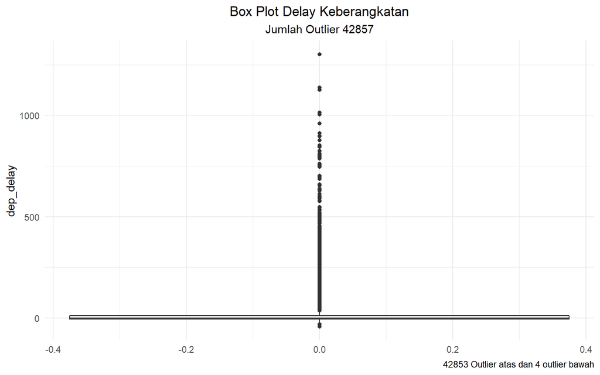

```r
out <- boxplot.stats(data$dep_delay)$out
outPositif <- sum(out > 0)
outNegatif <- length(out) - outPositif
data %>%
      ggplot(aes(y = dep_delay)) +
      geom_boxplot() +
      labs(title = "Box Plot Delay Keberangkatan",
           subtitle = paste("Jumlah Outlier", length(out)),
           caption = paste(outPositif, "Outlier atas dan", outNegatif, "outlier bawah")) +
      theme_minimal() +
      theme(plot.title = element_text(hjus = 0.5),
            plot.subtitle = element_text(hjus = 0.5))
```

```r
data[which.max(data$dep_delay), ]
```

```
## # A tibble: 1 x 23
##   month   day dep_time            sched_dep_time      dep_delay arr_delay
##   <int> <int> <dttm>              <dttm>                  <dbl>     <dbl>
## 1     1     9 2013-01-10 06:41:00 2013-01-09 09:00:00      1301      1272
## # ... with 17 more variables: carrier <chr>, tailnum <chr>, origin <chr>,
## #   dest <chr>, distance <dbl>, hour <dbl>, time_hour <dttm>, temp <dbl>,
## #   humid <dbl>, wind_speed <dbl>, pressure <dbl>, visib <dbl>,
## #   dep_airport <chr>, dest_airport <chr>, year_aiplane <int>, engine <chr>,
## #   name <chr>
```

Dari 5 summary, terlihat bahwa ada penerbangan yang delay hingga 1301 menit, atau sekitar 21 jam. Delay terlama itu ternyata terjadi pada tanggal 9 Januari. Penerbangan tersebut adalah penerbangan dari Bandara John F Kennedy ke Bandara Honolulu. Penerbangan tersebut dijadwalkan berangkat padad jama 9 pagi akan tetapi baru berhasil berangkat pada esok harinya jam 6:41 pagi. Maskapai dari penerbangan tersebut adalah Hawaiian Airlines Inc.

### Melihat delay per bandara keberangkatan

```r
tapply(data$dep_delay, data$dep_airport, function(x){
      jml <- length(x)
      c(jumlah = jml,
           cepat_berangkat = round(sum(x < 0) / jml * 100, 1) ,
           tepat = round(sum(x == 0)/jml * 100, 1),
           lama_berangkat = round(sum(x > 0) / jml * 100, 1))
})
```

```
## $`John F Kennedy Intl`
##          jumlah cepat_berangkat           tepat  lama_berangkat
##        109079.0            55.9             5.7            38.4
##
## $`La Guardia`
##          jumlah cepat_berangkat           tepat  lama_berangkat
##        101140.0            62.3             4.6            33.1
##
## $`Newark Liberty Intl`
##          jumlah cepat_berangkat           tepat  lama_berangkat
##        117127.0            50.5             4.8            44.7
```

Terlihat bahwa ditiga bandara tersebut persentasi yang lebih cepat berangkat selalu lebih besar dari persentasi yang lambar berangkat. Jika dilihat bandara yang tepat waktu adalah bandara John F Kennedy, sebesar 5.7 persen penerbangannya tepat sesuai dengan yang di jadwalkan, sedangkan untuk bandara yang paling sering delay adalah bandara Newark Liberty dengan persentase 44.7 penerbangan delay pada tahun 2013.

```r
perBandara <- split(data$dep_delay, data$dep_airport)
sapply(perBandara, summary)
```

```
##         John F Kennedy Intl La Guardia Newark Liberty Intl
## Min.              -43.00000  -33.00000           -25.00000
## 1st Qu.            -5.00000   -6.00000            -4.00000
## Median             -1.00000   -3.00000            -1.00000
## Mean               12.02361   10.28658            15.00911
## 3rd Qu.            10.00000    7.00000            15.00000
## Max.             1301.00000  911.00000          1126.00000
```

```r
maxDelay <- sapply(perBandara, which.max)
data[maxDelay, ]
```

```
## # A tibble: 3 x 23
##   month   day dep_time            sched_dep_time      dep_delay arr_delay
##   <int> <int> <dttm>              <dttm>                  <dbl>     <dbl>
## 1     1     3 2013-01-03 18:19:00 2013-01-03 18:20:00        -1       -42
## 2    10    22 2013-10-22 13:55:00 2013-10-22 13:55:00         0        -9
## 3     1     4 2013-01-04 11:00:00 2013-01-04 11:00:00         0       -49
## # ... with 17 more variables: carrier <chr>, tailnum <chr>, origin <chr>,
## #   dest <chr>, distance <dbl>, hour <dbl>, time_hour <dttm>, temp <dbl>,
## #   humid <dbl>, wind_speed <dbl>, pressure <dbl>, visib <dbl>,
## #   dep_airport <chr>, dest_airport <chr>, year_aiplane <int>, engine <chr>,
## #   name <chr>
```

```r
data %>%
      select(dep_delay, dep_airport) %>%
      group_by(dep_airport) %>%
      mutate(dep_delay = round(dep_delay / 60)) %>%
      filter(dep_delay != 0) %>%
      count(dep_delay) %>%
      arrange(dep_airport, dep_delay) %>%
      rename(dep_delay_jam = dep_delay)
```

```
## # A tibble: 52 x 3
## # Groups:   dep_airport [3]
##    dep_airport         dep_delay_jam     n
##    <chr>                       <dbl> <int>
##  1 John F Kennedy Intl            -1     1
##  2 John F Kennedy Intl             1 10154
##  3 John F Kennedy Intl             2  3141
##  4 John F Kennedy Intl             3  1140
##  5 John F Kennedy Intl             4   433
##  6 John F Kennedy Intl             5   159
##  7 John F Kennedy Intl             6    59
##  8 John F Kennedy Intl             7    18
##  9 John F Kennedy Intl             8     6
## 10 John F Kennedy Intl             9     1
## # ... with 42 more rows
```

Dari tabel diatas terlihat bahwa di ketiga bandara tersebut jumlah penerebangan yang delay kurang lebih sejam merupakan yang terbanyak. Penerbangan yang delay kurang lebih 4 jam hanya sekitar 400-500 di setiap Bandara. Sementara itu untuk delay yang lebih dari 6 jam di Bandara John F Kennedy sebanyak 103 penerbangan, di Bandara La Guardia sebanyak 149 penerbangan, dan di Bandara Newark Liberty 129 penerbangan. Dari beberapa hal yang telah disebutkan diatas, dapat diketahu bahwa kinerja ketiga bandara tersebut relatif sama.

Sebelumnya saya akan memisahkan delay yang positif dan negatif

```r
cepatBerangkat <- filter(data, dep_delay < 0)
lambatBerangkat <- filter(data, dep_delay > 0)
```

### Pola Delay Per Bulan

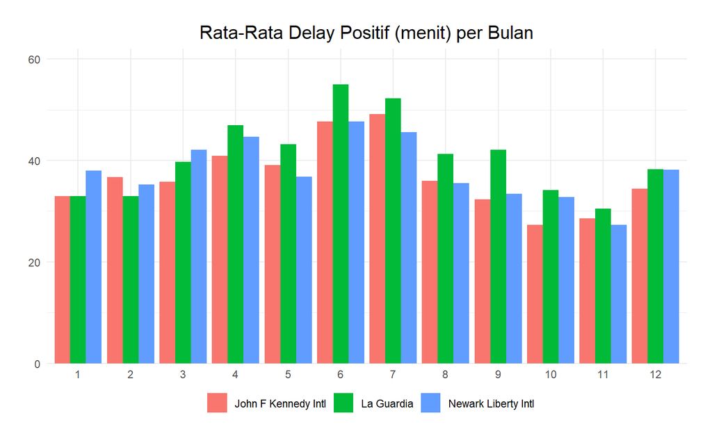

```r
lambatBerangkat %>%
      group_by(dep_airport, month) %>%
      summarise(jumlah = round(mean(dep_delay), 1)) %>%
      ggplot() +
      geom_col(aes(x = factor(month), y = jumlah, fill = dep_airport), position = "dodge") +
      scale_y_continuous(expand = c(0, 0), limits = c(0, 62)) +
      labs(fill = "",
           title = "Rata-Rata Delay Positif (menit) per Bulan",
           x = "",
           y = "") +
      theme_minimal() +
      theme(legend.position = "bottom",
            plot.title = element_text(hjust = 0.5, size = 15),
            plot.margin = margin(c(20,20,20,10)),
            legend.box.margin = margin(-20, 0, 0, 0))
```

```r
data %>%
      count(month) %>%
      arrange(desc(n)) %>%
      rename(jumlah_penerbangan = n)
```

```
## # A tibble: 12 x 2
##    month jumlah_penerbangan
##    <int>              <int>
##  1     8              28756
##  2    10              28618
##  3     7              28293
##  4     5              28128
##  5     3              27902
##  6     4              27564
##  7     6              27075
##  8    12              27020
##  9     9              27010
## 10    11              26971
## 11     1              26398
## 12     2              23611
```

Terlihat bahwa rata-rata delay terlama pada tahan 2013 terjadi pada bulan Juni dan Juli. Sementara itu pada bulan Agustus dan Oktober yang memiliki jumlah penerbangan terbanyak malah memiliki rata-rata delay yang lebih rebdah dari bulan Juni dan Juli. Ini mengindikasikan ada sesuatu yang terjadi pada bulan Juni dan Juli hingga menyebabkan rata-rata waktu delay terlama.

### Pola Delay Perjam

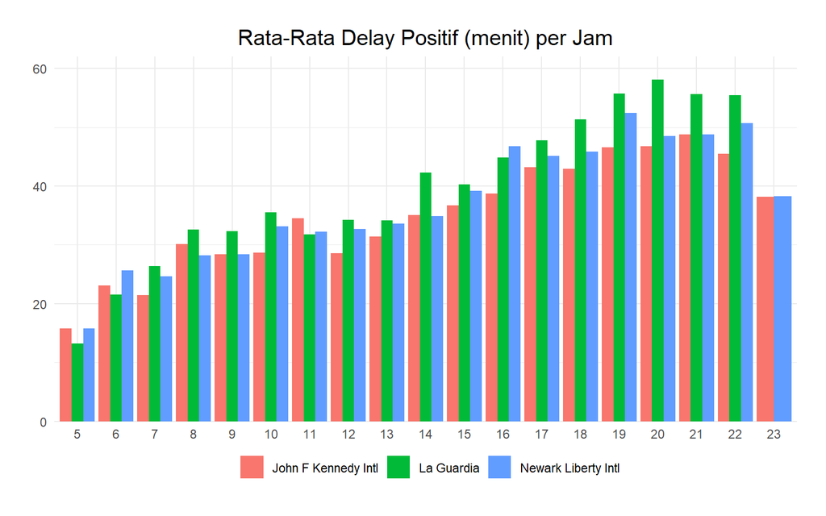

```r
lambatBerangkat %>%
      group_by(dep_airport, hour) %>%
      summarise(jumlah = round(mean(dep_delay), 1)) %>%
      ggplot() +
      geom_col(aes(x = factor(hour), y = jumlah, fill = dep_airport), position = "dodge") +
      scale_y_continuous(expand = c(0, 0), limits = c(0, 62)) +
      labs(fill = "",
           title = "Rata-Rata Delay Positif (menit) per Jam",
           x = "",
           y = "") +
      theme_minimal() +
      theme(legend.position = "bottom",
            plot.title = element_text(hjust = 0.5, size = 15),
            plot.margin = margin(c(20,20,20,10)),
            legend.box.margin = margin(-20, 0, 0, 0))
```

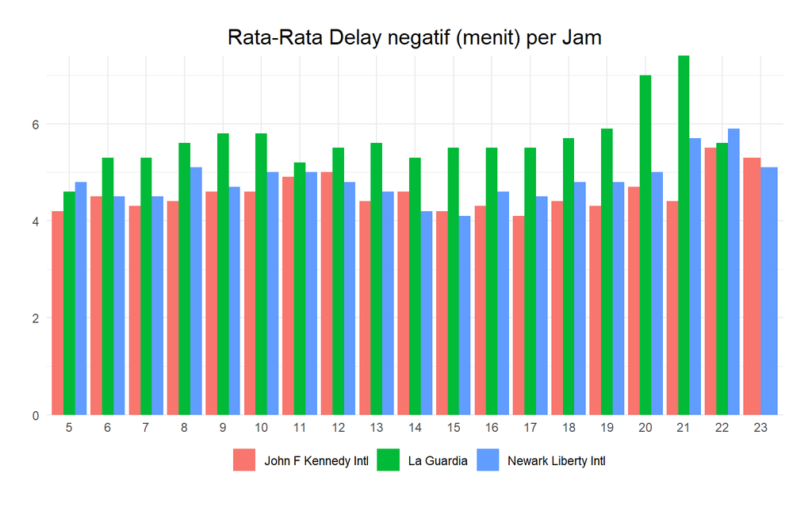

```r
cepatBerangkat %>%
      group_by(dep_airport, hour) %>%
      summarise(jumlah = round(mean(abs(dep_delay)), 1)) %>%
      ggplot() +
      geom_col(aes(x = factor(hour), y = jumlah, fill = dep_airport), position = "dodge") +
      scale_y_continuous(expand = c(0, 0)) +
      labs(fill = "",
           title = "Rata-Rata Delay negatif (menit) per Jam",
           x = "",
           y = "") +
      theme_minimal() +
      theme(legend.position = "bottom",
            plot.title = element_text(hjust = 0.5, size = 15),
            plot.margin = margin(c(20,20,20,10)),
            legend.box.margin = margin(-20, 0, 0, 0))
```

Sementara untuk delay yang negatif tidak terlihat pola yang signifikan. Jika dilihat dari delay rata-ratanya tidak mencapai 10 menit. Keberangkatan yang lebih cepat ternyata tidak terlalu signifikan dan masih dapat dianggap tepat waktu, karena bahkan tidak melebihi 10 menit.

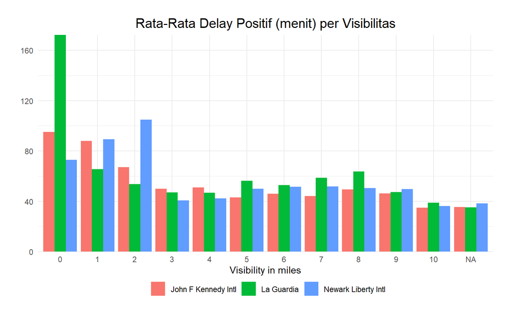

```r
lambatBerangkat %>%
      group_by(dep_airport, visib) %>%
      summarise(jumlah = round(mean(abs(dep_delay)), 1)) %>%
      ggplot() +
      geom_col(aes(x = factor(round(visib)), y = jumlah, fill = dep_airport), position = "dodge") +
      scale_y_continuous(expand = c(0, 0)) +
      labs(fill = "",
           title = "Rata-Rata Delay Positif (menit) per Visibilitas",
           x = "Visibility in miles",
           y = "") +
      theme_minimal() +
      theme(legend.position = "bottom",
            plot.title = element_text(hjust = 0.5, size = 15),
            plot.margin = margin(c(20,20,20,10)),
            legend.box.margin = margin(-10, 0, 0, 0))
```

Jika dilihat berdasarkan visibilitas pandangan di udara, semakin kecil visibilitas maka semakin tinggi rata-rata delay. Ini adalah sesuatu yang wajar karena suatu penerbangan tidak akan mengambil resiko jika jarak pandang diudaranya sangat pendek.

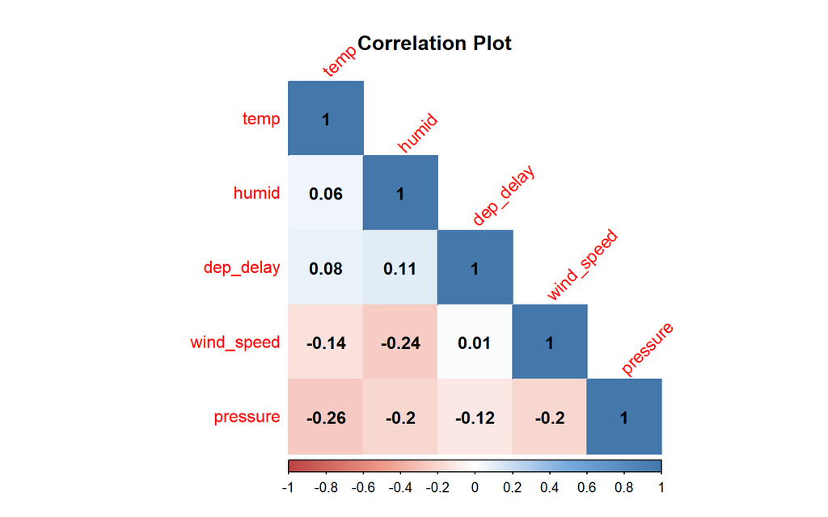

```
## numeric(0)
```

```r
col <- colorRampPalette(c("#BB4444", "#EE9988", "#FFFFFF", "#77AADD", "#4477AA"))
correlation <- lambatBerangkat %>%
                  select(wind_speed, pressure, humid, dep_delay, temp) %>%
                  na.omit() %>% cor()

col <- colorRampPalette(c("#BB4444", "#EE9988", "#FFFFFF", "#77AADD", "#4477AA"))
corrplot(correlation, method = "color", type="lower", col = col(200), tl.srt=45,
         addCoef.col = "black", order="hclust") +
title("Correlation Plot")
```

Dari korelasi plot diatas tidak didapati korelasi yang signifikan antara delay keberangkatan penerbangan tahun 2013 dengan keadaan cuaca seperti wind_speed, pressure, temperature, dan humadity

## Soal 2

Carrier mana yang memiliki kinerja paling baik dan paling buruk selama tahun 2013? Which carriers have been the top and the bottom performers in 2013? Pertanyaan ini akan membantu kita mengidentifikasi carrier mana yang memiliki kinerja buruk sepanjang 2013. Informasi ini dapat menginformasikan masyarakat untuk menghindari berpergian dengan carrier tersebut.

Untuk melihat kinerja dari maskapai saya akan menggunakan 3 indikator

### Indikator 1

Indikator pertama adalah ketepatan keberangkatan dan kedatangan sesuai dengan jadwal

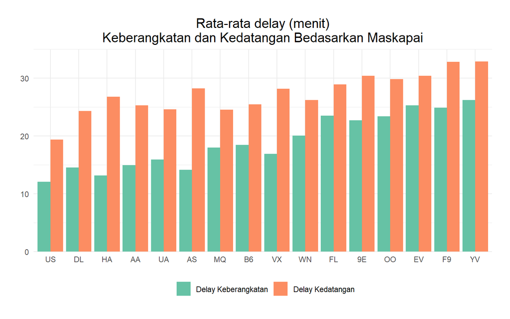

```r
data %>%
      mutate(dep_delay = abs(dep_delay),
             arr_delay = abs(arr_delay)) %>%
      select(dep_delay, arr_delay, carrier, name) %>%
      group_by(carrier) %>%
      summarise(mean_dep_delay = mean(dep_delay),
                mean_arr_delay = mean(arr_delay)) %>%
      melt() %>%
      ggplot() +
      geom_col(aes(x = reorder(carrier, value),
                   y = value,
                   fill = variable),
               position = "dodge") +
      labs(title = "Rata-rata delay (menit)\nKeberangkatan dan Kedatangan Bedasarkan Maskapai",
           fill = "",
           x = "",
           y = "") +
      scale_y_continuous(expand = c(0, NA), limits = c(0, 35)) +
      scale_fill_brewer(labels = c("Delay Keberangkatan", "Delay Kedatangan"),
                        palette = "Set2") +
      theme_minimal() +
      theme(legend.position = "bottom",
            plot.title = element_text(hjust = 0.5, size = 15),
            plot.margin = margin(c(20,20,20,10)),
            legend.box.margin = margin(-10, 0, 0, 0))
```

Telihat berdasarkan indikator ini maskapai yang sering delay baik keberangkatan maupun kedatangan adalah maskapai Mesa Airlines Inc. Sementara itu maskapai yang sangat baik dalam indikator ini adalah maskapai US Airways Inc.

### Indikator Dua

Indikator kedua adalah kesesuaian lama diudara. Misalanya jika keberangkatan delay 2 menit maka maksimal kedatangan juga maksimal delay 2 menit, jika lebih dari itu maka akan dianggap tidak wajar, karena melebihi waktu penerbangan yang sesungguhnya.

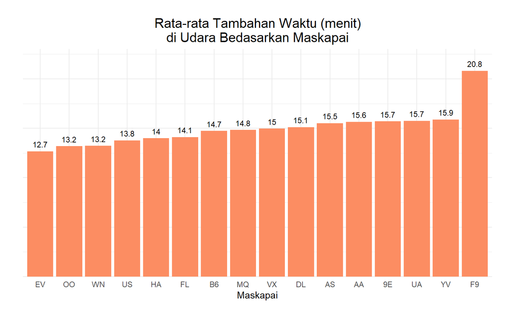

```r
data %>%
      filter(arr_delay > dep_delay) %>%
      mutate(tambahan_diudara = arr_delay - dep_delay) %>%
      select(tambahan_diudara, carrier) %>%
      group_by(carrier) %>%
      summarise(jumlah = mean(tambahan_diudara)) %>%
      arrange(jumlah) %>%
      ggplot(aes(x = reorder(carrier, jumlah),
                   y = jumlah)) +
      geom_col(fill = "#fc8d62") +
      geom_text(aes(label = round(jumlah, 1)), vjust = -0.7, size = 3) +
      labs(title = "Rata-rata Tambahan Waktu (menit)\ndi Udara Bedasarkan Maskapai",
           x = "Maskapai",
           y = "") +
      scale_y_continuous(expand = c(0, NA), limits = c(0, 23)) +
      theme_minimal() +
      theme(legend.position = "bottom",
            plot.title = element_text(hjust = 0.5, size = 15),
            plot.margin = margin(c(20,20,20,10)),
            legend.box.margin = margin(-10, 0, 0, 0),
            axis.text.y = element_blank())
```

Dari gambar diatas terlihat bahwa rata-rata penambahan waktu di udara yang terlama adalah maskapai Frontier Airlines Inc. dengan rata-rata 20.8 menit. Sementara itu maskapai yang memiliki rata-rata penambahan waktu paling sedikit adalah maskapai ExpressJet Airlines Inc.

### Indikator ketiga

Indikator ketiga adalah tahun keluaran pesawat yang dimiliki oleh maskapai

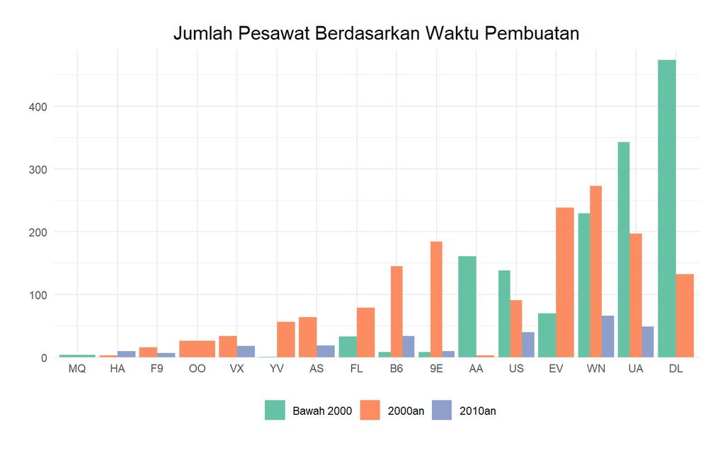

```r
tmp <- data %>%
      distinct(tailnum, carrier, .keep_all = TRUE) %>%
      select(year_aiplane, carrier) %>%
      na.omit()
tmp$year_aiplane <- cut(tmp$year_aiplane,
                        breaks = c(1940, 2000, 2010, 2020),
                        labels = c("Bawah 2000", "2000an", "2010an"))

tmp %>%
      group_by(carrier, year_aiplane) %>%
      summarise(jumlah = n()) %>%
      ggplot(aes(x = reorder(carrier, jumlah), y = jumlah, fill = year_aiplane)) +
      geom_col(position = "dodge") +
      labs(title = "Jumlah Pesawat Berdasarkan Waktu Pembuatan",
           fill = "",
           x = "",
           y = "") +
      scale_y_continuous(expand = c(0, NA), limits = c(0, 490)) +
      scale_fill_brewer(palette = "Set2") +
      theme_minimal() +
      theme(legend.position = "bottom",
            plot.title = element_text(hjust = 0.5, size = 15),
            plot.margin = margin(c(20,20,20,10)),
            legend.box.margin = margin(-10, 0, 0, 0))
```

Dari gambar diatas terlihat bahwa maskapai Envoy Air (MQ) hanya memiliki pesawat buatan tahun 2000 kebawah. Begitu juga dengan maskapai Delta Air Lines Inc. (DL) masih banyak menggunakan pesawat buatan tahun 2000 kebawah, tentu saja hal ini dapat menjadi pertimbangan dalam menentukan maskapai yang akan digunakan. Semakin tua pesawat maka akan semakin beresiko pesawat itu.

Sementara itu maskapai dengan jumlah pesawat terbanyak buatan 2010an keatas adalah maskapai Southwest Airlines Co (VN) dan terdapat juga beberapa maskapai lainnya yang sudah memiliki pesawat buatan 2010an keatas.

### Kesimpulan

Dari beberapa penjelasan diatas untuk menentukan carrier yang mempunyai performa terbaik dapat dilihat dari carrier yang paling sesuai dengan jadwal keberangkatan maupun kedatangan dan lama waktu di udara yang sesuai. Dari hasil analisis diperoleh bahwa maskapai US Airways Inc yang memiliki performa terbaik karena pada indikator satu menduduki peringkat pertama dan indikator dua memduduki urutan ke 4.

Selain itu, untuk masyarakat dapat menghindari pemakaian carrier dengan melihat jenis pesawat yang digunakan oleh maskapai tersebut, terutama dari segi waktu pembuatan pesawat tersebut